# BoJack Hoseman e os feels

Bojack Horseman é uma animação focada em seus personagens, que aborda temas delicados como depressão, demência e complexos destrutivos. Dito isso, os episódios mexem tanto com os personagens, quanto com os seus telespectadores.

Nesse sentido, queremos saber se os episódios mais vistos são justamente aqueles que apresentam uma mudança no comportamento dos personagens em questão e/ou uma explicação passada que justifica suas ações no presente, resultando em uma conexão pessoal com o telespectador.

A única medida que melhor se aproxima da quantidade de visualizações é a quantidade de votos, logo, compararemos a popularidade de todos os episódios da série.

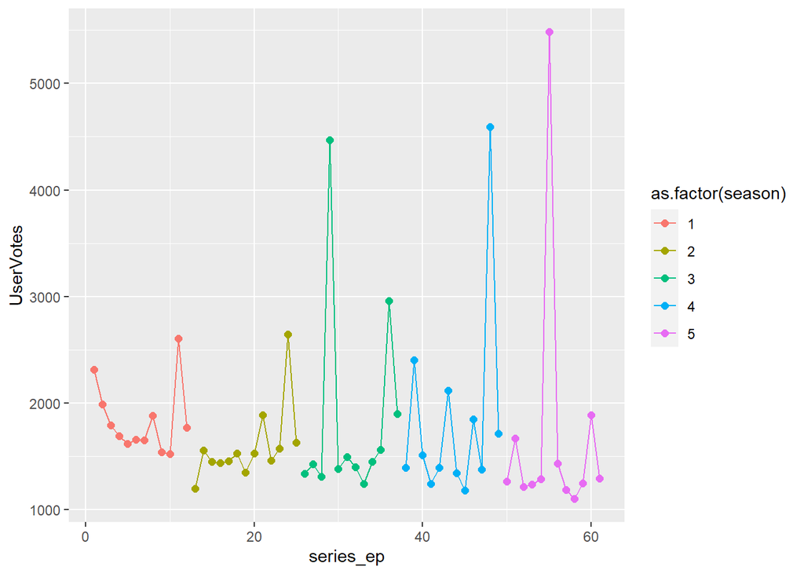

```r
bojack = series %>% filter(series_name=="BoJack Horseman")
bojack %>% ggplot(mapping = aes(x = series_ep,y = UserVotes,color = as.factor(season)))+
geom_point(size = 2)+
geom_line()
```

Os episódios mais votados foram Free Churros e Time’s Arrow. Sendo que o primeiro é um monólogo do personagem principal sobre sua mãe que veio à falecer. Enquanto o segundo mostra a trajetória da mãe do personagem principal, que passou de uma criança traumatizada, para uma garota brilhante e confiante, para uma mãe amarga e detestável.

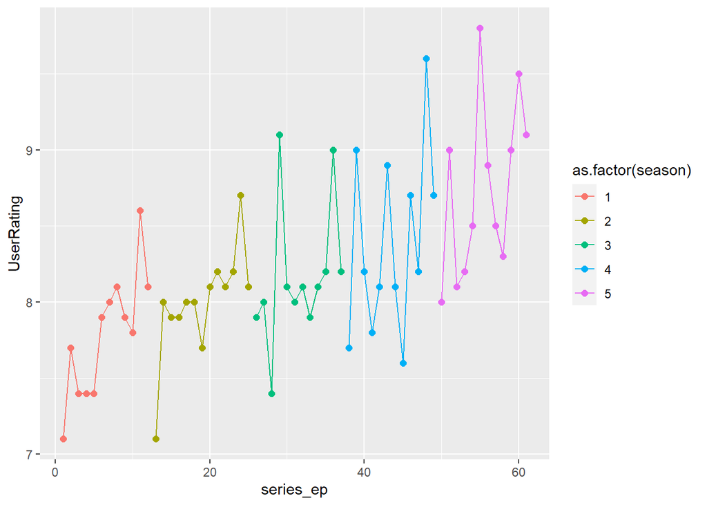

```r
bojack = series %>% filter(series_name=="BoJack Horseman")
bojack %>% ggplot(mapping = aes(x = series_ep,y = UserRating,color = as.factor(season)))+
geom_point(size = 2)+
geom_line()
```

Esses mesmos episódios são também os de maior nota. É possível notar, pela vizualização de ambos os gráficos que os picos não se mantêm. Isso ocorre porque, pelo menos para os picos, a narrativa se torna pessoal e sincera, de tal forma que são exaustivamente discutidos em foruns ou vídeos pela internet, enquanto os demais episódios, à sua maneira, retratam as eventualidades nos cotidianos de cada personagem.